# Risk Factor Analysis

## Outcome Variable

**Outcome Variable:** swasted

## Predictor Variables

**Intervention Variable:** month

**Adjustment Set:**

unadjusted

## Stratifying Variables

The analysis was stratified on these variable(s):

- agecat
- studyid
- country

## Data Summary

| agecat | studyid | country | month | swasted | n_cell | n |
| --- | --- | --- | --- | --- | --- | --- |
| Birth | CMC-V-BCS-2002 | INDIA | 1 | 0 | 9 | 86 |
| Birth | CMC-V-BCS-2002 | INDIA | 1 | 1 | 0 | 86 |
| Birth | CMC-V-BCS-2002 | INDIA | 2 | 0 | 1 | 86 |
| Birth | CMC-V-BCS-2002 | INDIA | 2 | 1 | 0 | 86 |
| Birth | CMC-V-BCS-2002 | INDIA | 3 | 0 | 7 | 86 |
| Birth | CMC-V-BCS-2002 | INDIA | 3 | 1 | 0 | 86 |
| Birth | CMC-V-BCS-2002 | INDIA | 4 | 0 | 9 | 86 |
| Birth | CMC-V-BCS-2002 | INDIA | 4 | 1 | 0 | 86 |
| Birth | CMC-V-BCS-2002 | INDIA | 5 | 0 | 9 | 86 |
| Birth | CMC-V-BCS-2002 | INDIA | 5 | 1 | 0 | 86 |
| Birth | CMC-V-BCS-2002 | INDIA | 6 | 0 | 10 | 86 |
| Birth | CMC-V-BCS-2002 | INDIA | 6 | 1 | 0 | 86 |
| Birth | CMC-V-BCS-2002 | INDIA | 7 | 0 | 7 | 86 |
| Birth | CMC-V-BCS-2002 | INDIA | 7 | 1 | 0 | 86 |
| Birth | CMC-V-BCS-2002 | INDIA | 8 | 0 | 4 | 86 |
| Birth | CMC-V-BCS-2002 | INDIA | 8 | 1 | 0 | 86 |
| Birth | CMC-V-BCS-2002 | INDIA | 9 | 0 | 7 | 86 |
| Birth | CMC-V-BCS-2002 | INDIA | 9 | 1 | 1 | 86 |
| Birth | CMC-V-BCS-2002 | INDIA | 10 | 0 | 8 | 86 |
| Birth | CMC-V-BCS-2002 | INDIA | 10 | 1 | 0 | 86 |
| Birth | CMC-V-BCS-2002 | INDIA | 11 | 0 | 11 | 86 |
| Birth | CMC-V-BCS-2002 | INDIA | 11 | 1 | 0 | 86 |
| Birth | CMC-V-BCS-2002 | INDIA | 12 | 0 | 3 | 86 |
| Birth | CMC-V-BCS-2002 | INDIA | 12 | 1 | 0 | 86 |
| Birth | CMIN | BANGLADESH | 1 | 0 | 0 | 19 |
| Birth | CMIN | BANGLADESH | 1 | 1 | 0 | 19 |
| Birth | CMIN | BANGLADESH | 2 | 0 | 4 | 19 |
| Birth | CMIN | BANGLADESH | 2 | 1 | 0 | 19 |
| Birth | CMIN | BANGLADESH | 3 | 0 | 2 | 19 |
| Birth | CMIN | BANGLADESH | 3 | 1 | 0 | 19 |

[output cut: 1578 more lines]

The following strata were considered:

- agecat: 24 months, studyid: CMC-V-BCS-2002, country: INDIA
- agecat: 24 months, studyid: CMIN, country: BANGLADESH
- agecat: 24 months, studyid: CONTENT, country: PERU
- agecat: 24 months, studyid: EE, country: PAKISTAN
- agecat: 24 months, studyid: GMS-Nepal, country: NEPAL
- agecat: 24 months, studyid: IRC, country: INDIA
- agecat: 24 months, studyid: JiVitA-3, country: BANGLADESH
- agecat: 24 months, studyid: JiVitA-4, country: BANGLADESH
- agecat: 24 months, studyid: Keneba, country: GAMBIA
- agecat: 24 months, studyid: LCNI-5, country: MALAWI
- agecat: 24 months, studyid: MAL-ED, country: BANGLADESH
- agecat: 24 months, studyid: MAL-ED, country: BRAZIL
- agecat: 24 months, studyid: MAL-ED, country: INDIA
- agecat: 24 months, studyid: MAL-ED, country: NEPAL
- agecat: 24 months, studyid: MAL-ED, country: PERU
- agecat: 24 months, studyid: MAL-ED, country: SOUTH AFRICA
- agecat: 24 months, studyid: MAL-ED, country: TANZANIA, UNITED REPUBLIC OF
- agecat: 24 months, studyid: NIH-Birth, country: BANGLADESH
- agecat: 24 months, studyid: PROBIT, country: BELARUS
- agecat: 24 months, studyid: TanzaniaChild2, country: TANZANIA, UNITED REPUBLIC OF
- agecat: 24 months, studyid: ZVITAMBO, country: ZIMBABWE
- agecat: 6 months, studyid: CMC-V-BCS-2002, country: INDIA
- agecat: 6 months, studyid: CMIN, country: BANGLADESH
- agecat: 6 months, studyid: CONTENT, country: PERU
- agecat: 6 months, studyid: EE, country: PAKISTAN
- agecat: 6 months, studyid: GMS-Nepal, country: NEPAL
- agecat: 6 months, studyid: Guatemala BSC, country: GUATEMALA
- agecat: 6 months, studyid: IRC, country: INDIA
- agecat: 6 months, studyid: JiVitA-3, country: BANGLADESH
- agecat: 6 months, studyid: JiVitA-4, country: BANGLADESH
- agecat: 6 months, studyid: Keneba, country: GAMBIA
- agecat: 6 months, studyid: LCNI-5, country: MALAWI
- agecat: 6 months, studyid: MAL-ED, country: BANGLADESH
- agecat: 6 months, studyid: MAL-ED, country: BRAZIL
- agecat: 6 months, studyid: MAL-ED, country: INDIA
- agecat: 6 months, studyid: MAL-ED, country: NEPAL
- agecat: 6 months, studyid: MAL-ED, country: PERU
- agecat: 6 months, studyid: MAL-ED, country: SOUTH AFRICA
- agecat: 6 months, studyid: MAL-ED, country: TANZANIA, UNITED REPUBLIC OF
- agecat: 6 months, studyid: NIH-Birth, country: BANGLADESH
- agecat: 6 months, studyid: PROBIT, country: BELARUS
- agecat: 6 months, studyid: ResPak, country: PAKISTAN
- agecat: 6 months, studyid: SAS-CompFeed, country: INDIA
- agecat: 6 months, studyid: SAS-FoodSuppl, country: INDIA
- agecat: 6 months, studyid: TanzaniaChild2, country: TANZANIA, UNITED REPUBLIC OF
- agecat: 6 months, studyid: ZVITAMBO, country: ZIMBABWE
- agecat: Birth, studyid: CMC-V-BCS-2002, country: INDIA
- agecat: Birth, studyid: CMIN, country: BANGLADESH
- agecat: Birth, studyid: CONTENT, country: PERU
- agecat: Birth, studyid: EE, country: PAKISTAN
- agecat: Birth, studyid: GMS-Nepal, country: NEPAL
- agecat: Birth, studyid: IRC, country: INDIA
- agecat: Birth, studyid: JiVitA-3, country: BANGLADESH
- agecat: Birth, studyid: JiVitA-4, country: BANGLADESH
- agecat: Birth, studyid: Keneba, country: GAMBIA
- agecat: Birth, studyid: MAL-ED, country: BANGLADESH
- agecat: Birth, studyid: MAL-ED, country: BRAZIL
- agecat: Birth, studyid: MAL-ED, country: INDIA
- agecat: Birth, studyid: MAL-ED, country: NEPAL
- agecat: Birth, studyid: MAL-ED, country: PERU
- agecat: Birth, studyid: MAL-ED, country: SOUTH AFRICA
- agecat: Birth, studyid: MAL-ED, country: TANZANIA, UNITED REPUBLIC OF
- agecat: Birth, studyid: NIH-Birth, country: BANGLADESH
- agecat: Birth, studyid: PROBIT, country: BELARUS
- agecat: Birth, studyid: ResPak, country: PAKISTAN
- agecat: Birth, studyid: SAS-CompFeed, country: INDIA
- agecat: Birth, studyid: ZVITAMBO, country: ZIMBABWE

### Dropped Strata

Some strata were dropped due to rare outcomes:

- agecat: Birth, studyid: CMC-V-BCS-2002, country: INDIA
- agecat: Birth, studyid: CMIN, country: BANGLADESH
- agecat: Birth, studyid: CONTENT, country: PERU
- agecat: Birth, studyid: EE, country: PAKISTAN
- agecat: Birth, studyid: GMS-Nepal, country: NEPAL
- agecat: Birth, studyid: IRC, country: INDIA
- agecat: Birth, studyid: JiVitA-4, country: BANGLADESH
- agecat: Birth, studyid: Keneba, country: GAMBIA
- agecat: Birth, studyid: MAL-ED, country: BANGLADESH
- agecat: Birth, studyid: MAL-ED, country: BRAZIL
- agecat: Birth, studyid: MAL-ED, country: INDIA
- agecat: Birth, studyid: MAL-ED, country: NEPAL
- agecat: Birth, studyid: MAL-ED, country: PERU
- agecat: Birth, studyid: MAL-ED, country: SOUTH AFRICA
- agecat: Birth, studyid: MAL-ED, country: TANZANIA, UNITED REPUBLIC OF
- agecat: Birth, studyid: NIH-Birth, country: BANGLADESH
- agecat: Birth, studyid: ResPak, country: PAKISTAN
- agecat: Birth, studyid: SAS-CompFeed, country: INDIA
- agecat: 6 months, studyid: CMC-V-BCS-2002, country: INDIA
- agecat: 6 months, studyid: CMIN, country: BANGLADESH
- agecat: 6 months, studyid: CONTENT, country: PERU
- agecat: 6 months, studyid: EE, country: PAKISTAN
- agecat: 6 months, studyid: GMS-Nepal, country: NEPAL
- agecat: 6 months, studyid: Guatemala BSC, country: GUATEMALA
- agecat: 6 months, studyid: IRC, country: INDIA
- agecat: 6 months, studyid: JiVitA-4, country: BANGLADESH
- agecat: 6 months, studyid: Keneba, country: GAMBIA
- agecat: 6 months, studyid: LCNI-5, country: MALAWI
- agecat: 6 months, studyid: MAL-ED, country: BANGLADESH
- agecat: 6 months, studyid: MAL-ED, country: BRAZIL
- agecat: 6 months, studyid: MAL-ED, country: INDIA
- agecat: 6 months, studyid: MAL-ED, country: NEPAL
- agecat: 6 months, studyid: MAL-ED, country: PERU
- agecat: 6 months, studyid: MAL-ED, country: SOUTH AFRICA
- agecat: 6 months, studyid: MAL-ED, country: TANZANIA, UNITED REPUBLIC OF
- agecat: 6 months, studyid: NIH-Birth, country: BANGLADESH
- agecat: 6 months, studyid: PROBIT, country: BELARUS
- agecat: 6 months, studyid: ResPak, country: PAKISTAN
- agecat: 6 months, studyid: SAS-CompFeed, country: INDIA
- agecat: 6 months, studyid: SAS-FoodSuppl, country: INDIA
- agecat: 6 months, studyid: TanzaniaChild2, country: TANZANIA, UNITED REPUBLIC OF
- agecat: 6 months, studyid: ZVITAMBO, country: ZIMBABWE
- agecat: 24 months, studyid: CMC-V-BCS-2002, country: INDIA
- agecat: 24 months, studyid: CMIN, country: BANGLADESH
- agecat: 24 months, studyid: CONTENT, country: PERU
- agecat: 24 months, studyid: EE, country: PAKISTAN
- agecat: 24 months, studyid: GMS-Nepal, country: NEPAL
- agecat: 24 months, studyid: IRC, country: INDIA
- agecat: 24 months, studyid: JiVitA-4, country: BANGLADESH
- agecat: 24 months, studyid: Keneba, country: GAMBIA
- agecat: 24 months, studyid: LCNI-5, country: MALAWI
- agecat: 24 months, studyid: MAL-ED, country: BANGLADESH
- agecat: 24 months, studyid: MAL-ED, country: BRAZIL
- agecat: 24 months, studyid: MAL-ED, country: INDIA
- agecat: 24 months, studyid: MAL-ED, country: NEPAL
- agecat: 24 months, studyid: MAL-ED, country: PERU
- agecat: 24 months, studyid: MAL-ED, country: SOUTH AFRICA
- agecat: 24 months, studyid: MAL-ED, country: TANZANIA, UNITED REPUBLIC OF
- agecat: 24 months, studyid: NIH-Birth, country: BANGLADESH
- agecat: 24 months, studyid: PROBIT, country: BELARUS
- agecat: 24 months, studyid: TanzaniaChild2, country: TANZANIA, UNITED REPUBLIC OF
- agecat: 24 months, studyid: ZVITAMBO, country: ZIMBABWE

## Methods Detail

We’re interested in the causal parameters $E[Y_a]$ for all values of $a \in \mathcal{A}$. These parameters represent the mean outcome if, possibly contrary to fact, we intervened to set all units to have $A=a$. Under the randomization and positivity assumptions, these are identified by the statistical parameters $\psi_a=E_W[E_{Y|A,W}(Y|A=a,W)]$. In addition, we’re interested in the mean of $Y$, $E[Y]$ under no intervention (the observed mean). We will estimate these parameters by using SuperLearner to fit the relevant likelihood factors – $E_{Y|A,W}(Y|A=a,W)$ and $p(A=a|W)$, and then updating our likelihood fit using a joint TMLE.

For unadjusted analyses ($W=\{\}$), initial likelihoods were estimated using Lrnr_glm to estimate the simple $E(Y|A)$ and Lrnr_mean to estimate $p(A)$. For adjusted analyses, a small library containing Lrnr_glmnet, Lrnr_xgboost, and Lrnr_mean was used.

Having estimated these parameters, we will then use the delta method to estimate relative risks and attributable risks relative to a prespecified baseline level of $A$.

# Results Detail

## Results Plots

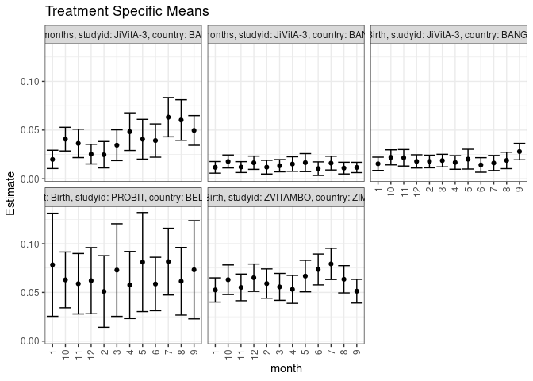

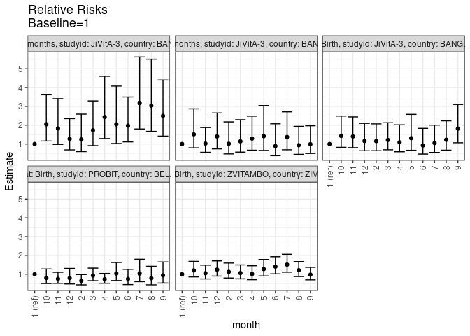

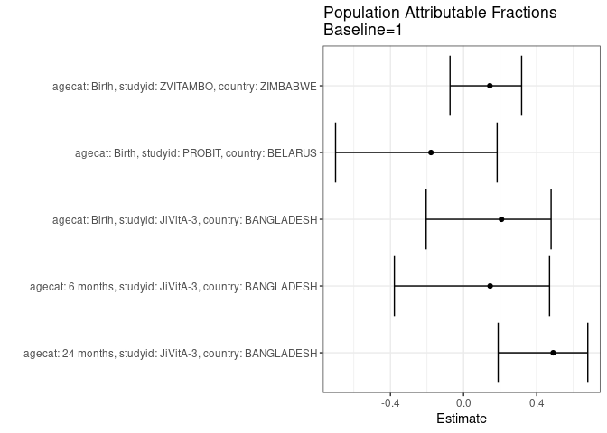

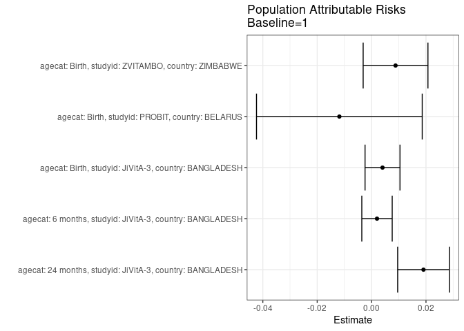

## Results Table

### Parameter: TSM

| agecat | studyid | country | intervention_level | baseline_level | estimate | ci_lower | ci_upper |
| --- | --- | --- | --- | --- | --- | --- | --- |
| Birth | JiVitA-3 | BANGLADESH | 1 | NA | 0.0153563 | 0.0085560 | 0.0221565 |
| Birth | JiVitA-3 | BANGLADESH | 2 | NA | 0.0177179 | 0.0112501 | 0.0241858 |
| Birth | JiVitA-3 | BANGLADESH | 3 | NA | 0.0186589 | 0.0122014 | 0.0251164 |
| Birth | JiVitA-3 | BANGLADESH | 4 | NA | 0.0167464 | 0.0097167 | 0.0237761 |
| Birth | JiVitA-3 | BANGLADESH | 5 | NA | 0.0201117 | 0.0099329 | 0.0302905 |
| Birth | JiVitA-3 | BANGLADESH | 6 | NA | 0.0141612 | 0.0066839 | 0.0216386 |
| Birth | JiVitA-3 | BANGLADESH | 7 | NA | 0.0161597 | 0.0084166 | 0.0239028 |
| Birth | JiVitA-3 | BANGLADESH | 8 | NA | 0.0188133 | 0.0103555 | 0.0272711 |
| Birth | JiVitA-3 | BANGLADESH | 9 | NA | 0.0279120 | 0.0194850 | 0.0363389 |
| Birth | JiVitA-3 | BANGLADESH | 10 | NA | 0.0219550 | 0.0141995 | 0.0297105 |
| Birth | JiVitA-3 | BANGLADESH | 11 | NA | 0.0215223 | 0.0130282 | 0.0300164 |
| Birth | JiVitA-3 | BANGLADESH | 12 | NA | 0.0178056 | 0.0109956 | 0.0246155 |
| Birth | PROBIT | BELARUS | 1 | NA | 0.0783626 | 0.0254535 | 0.1312716 |
| Birth | PROBIT | BELARUS | 2 | NA | 0.0509554 | 0.0141774 | 0.0877335 |
| Birth | PROBIT | BELARUS | 3 | NA | 0.0729167 | 0.0253949 | 0.1204385 |
| Birth | PROBIT | BELARUS | 4 | NA | 0.0575916 | 0.0231531 | 0.0920301 |
| Birth | PROBIT | BELARUS | 5 | NA | 0.0811380 | 0.0303012 | 0.1319748 |
| Birth | PROBIT | BELARUS | 6 | NA | 0.0586481 | 0.0312371 | 0.0860591 |
| Birth | PROBIT | BELARUS | 7 | NA | 0.0815686 | 0.0473146 | 0.1158227 |
| Birth | PROBIT | BELARUS | 8 | NA | 0.0614568 | 0.0267466 | 0.0961669 |
| Birth | PROBIT | BELARUS | 9 | NA | 0.0732265 | 0.0228061 | 0.1236470 |
| Birth | PROBIT | BELARUS | 10 | NA | 0.0628342 | 0.0341490 | 0.0915195 |
| Birth | PROBIT | BELARUS | 11 | NA | 0.0589080 | 0.0278971 | 0.0899190 |
| Birth | PROBIT | BELARUS | 12 | NA | 0.0620462 | 0.0280872 | 0.0960052 |
| Birth | ZVITAMBO | ZIMBABWE | 1 | NA | 0.0525040 | 0.0400792 | 0.0649288 |
| Birth | ZVITAMBO | ZIMBABWE | 2 | NA | 0.0590717 | 0.0440635 | 0.0740799 |
| Birth | ZVITAMBO | ZIMBABWE | 3 | NA | 0.0556604 | 0.0418582 | 0.0694626 |
| Birth | ZVITAMBO | ZIMBABWE | 4 | NA | 0.0531350 | 0.0388030 | 0.0674669 |
| Birth | ZVITAMBO | ZIMBABWE | 5 | NA | 0.0667396 | 0.0505594 | 0.0829198 |
| Birth | ZVITAMBO | ZIMBABWE | 6 | NA | 0.0735435 | 0.0577318 | 0.0893551 |
| Birth | ZVITAMBO | ZIMBABWE | 7 | NA | 0.0792350 | 0.0632579 | 0.0952120 |
| Birth | ZVITAMBO | ZIMBABWE | 8 | NA | 0.0634648 | 0.0494708 | 0.0774589 |
| Birth | ZVITAMBO | ZIMBABWE | 9 | NA | 0.0512618 | 0.0391230 | 0.0634006 |
| Birth | ZVITAMBO | ZIMBABWE | 10 | NA | 0.0630081 | 0.0478260 | 0.0781903 |
| Birth | ZVITAMBO | ZIMBABWE | 11 | NA | 0.0551402 | 0.0414632 | 0.0688172 |
| Birth | ZVITAMBO | ZIMBABWE | 12 | NA | 0.0650888 | 0.0510312 | 0.0791463 |
| 6 months | JiVitA-3 | BANGLADESH | 1 | NA | 0.0117130 | 0.0057331 | 0.0176930 |
| 6 months | JiVitA-3 | BANGLADESH | 2 | NA | 0.0118745 | 0.0048357 | 0.0189133 |
| 6 months | JiVitA-3 | BANGLADESH | 3 | NA | 0.0133803 | 0.0071069 | 0.0196536 |
| 6 months | JiVitA-3 | BANGLADESH | 4 | NA | 0.0151134 | 0.0076462 | 0.0225805 |
| 6 months | JiVitA-3 | BANGLADESH | 5 | NA | 0.0165650 | 0.0073055 | 0.0258244 |
| 6 months | JiVitA-3 | BANGLADESH | 6 | NA | 0.0103896 | 0.0034254 | 0.0173538 |
| 6 months | JiVitA-3 | BANGLADESH | 7 | NA | 0.0160643 | 0.0089888 | 0.0231397 |
| 6 months | JiVitA-3 | BANGLADESH | 8 | NA | 0.0109364 | 0.0048956 | 0.0169773 |
| 6 months | JiVitA-3 | BANGLADESH | 9 | NA | 0.0116054 | 0.0062843 | 0.0169266 |
| 6 months | JiVitA-3 | BANGLADESH | 10 | NA | 0.0177200 | 0.0110440 | 0.0243960 |
| 6 months | JiVitA-3 | BANGLADESH | 11 | NA | 0.0119832 | 0.0063884 | 0.0175781 |
| 6 months | JiVitA-3 | BANGLADESH | 12 | NA | 0.0164223 | 0.0096080 | 0.0232366 |
| 24 months | JiVitA-3 | BANGLADESH | 1 | NA | 0.0198582 | 0.0104403 | 0.0292760 |
| 24 months | JiVitA-3 | BANGLADESH | 2 | NA | 0.0246711 | 0.0111302 | 0.0382119 |
| 24 months | JiVitA-3 | BANGLADESH | 3 | NA | 0.0344353 | 0.0186333 | 0.0502372 |
| 24 months | JiVitA-3 | BANGLADESH | 4 | NA | 0.0483271 | 0.0290256 | 0.0676287 |
| 24 months | JiVitA-3 | BANGLADESH | 5 | NA | 0.0406091 | 0.0201888 | 0.0610295 |
| 24 months | JiVitA-3 | BANGLADESH | 6 | NA | 0.0392157 | 0.0221454 | 0.0562860 |
| 24 months | JiVitA-3 | BANGLADESH | 7 | NA | 0.0631741 | 0.0430267 | 0.0833216 |
| 24 months | JiVitA-3 | BANGLADESH | 8 | NA | 0.0602782 | 0.0394778 | 0.0810786 |
| 24 months | JiVitA-3 | BANGLADESH | 9 | NA | 0.0495868 | 0.0343835 | 0.0647901 |
| 24 months | JiVitA-3 | BANGLADESH | 10 | NA | 0.0406780 | 0.0285170 | 0.0528390 |
| 24 months | JiVitA-3 | BANGLADESH | 11 | NA | 0.0362860 | 0.0217160 | 0.0508560 |
| 24 months | JiVitA-3 | BANGLADESH | 12 | NA | 0.0252649 | 0.0152087 | 0.0353211 |

### Parameter: E(Y)

| agecat | studyid | country | intervention_level | baseline_level | estimate | ci_lower | ci_upper |
| --- | --- | --- | --- | --- | --- | --- | --- |
| Birth | JiVitA-3 | BANGLADESH | NA | NA | 0.0193738 | 0.0169653 | 0.0217823 |
| Birth | PROBIT | BELARUS | NA | NA | 0.0665123 | 0.0333611 | 0.0996634 |
| Birth | ZVITAMBO | ZIMBABWE | NA | NA | 0.0613145 | 0.0571772 | 0.0654519 |
| 6 months | JiVitA-3 | BANGLADESH | NA | NA | 0.0137035 | 0.0116269 | 0.0157801 |
| 24 months | JiVitA-3 | BANGLADESH | NA | NA | 0.0389399 | 0.0346167 | 0.0432631 |

### Parameter: RR

| agecat | studyid | country | intervention_level | baseline_level | estimate | ci_lower | ci_upper |
| --- | --- | --- | --- | --- | --- | --- | --- |
| Birth | JiVitA-3 | BANGLADESH | 1 | 1 | 1.0000000 | 1.0000000 | 1.0000000 |
| Birth | JiVitA-3 | BANGLADESH | 2 | 1 | 1.1537916 | 0.6430241 | 2.0702727 |
| Birth | JiVitA-3 | BANGLADESH | 3 | 1 | 1.2150671 | 0.6930551 | 2.1302606 |
| Birth | JiVitA-3 | BANGLADESH | 4 | 1 | 1.0905263 | 0.5882420 | 2.0216981 |
| Birth | JiVitA-3 | BANGLADESH | 5 | 1 | 1.3096760 | 0.6659562 | 2.5756215 |
| Birth | JiVitA-3 | BANGLADESH | 6 | 1 | 0.9221786 | 0.4641189 | 1.8323180 |
| Birth | JiVitA-3 | BANGLADESH | 7 | 1 | 1.0523194 | 0.5525336 | 2.0041786 |
| Birth | JiVitA-3 | BANGLADESH | 8 | 1 | 1.2251230 | 0.6724455 | 2.2320417 |
| Birth | JiVitA-3 | BANGLADESH | 9 | 1 | 1.8176275 | 1.0649877 | 3.1021669 |
| Birth | JiVitA-3 | BANGLADESH | 10 | 1 | 1.4297125 | 0.8225849 | 2.4849444 |
| Birth | JiVitA-3 | BANGLADESH | 11 | 1 | 1.4015328 | 0.8047153 | 2.4409802 |
| Birth | JiVitA-3 | BANGLADESH | 12 | 1 | 1.1594995 | 0.6404934 | 2.0990680 |
| Birth | PROBIT | BELARUS | 1 | 1 | 1.0000000 | 1.0000000 | 1.0000000 |
| Birth | PROBIT | BELARUS | 2 | 1 | 0.6502519 | 0.4320043 | 0.9787578 |
| Birth | PROBIT | BELARUS | 3 | 1 | 0.9305037 | 0.6543668 | 1.3231679 |
| Birth | PROBIT | BELARUS | 4 | 1 | 0.7349379 | 0.5184866 | 1.0417506 |
| Birth | PROBIT | BELARUS | 5 | 1 | 1.0354183 | 0.6612307 | 1.6213570 |
| Birth | PROBIT | BELARUS | 6 | 1 | 0.7484199 | 0.4457021 | 1.2567417 |
| Birth | PROBIT | BELARUS | 7 | 1 | 1.0409131 | 0.6035679 | 1.7951586 |
| Birth | PROBIT | BELARUS | 8 | 1 | 0.7842615 | 0.4331925 | 1.4198451 |
| Birth | PROBIT | BELARUS | 9 | 1 | 0.9344581 | 0.5285747 | 1.6520127 |
| Birth | PROBIT | BELARUS | 10 | 1 | 0.8018397 | 0.5033989 | 1.2772116 |
| Birth | PROBIT | BELARUS | 11 | 1 | 0.7517370 | 0.5134183 | 1.1006787 |
| Birth | PROBIT | BELARUS | 12 | 1 | 0.7917837 | 0.4800629 | 1.3059151 |
| Birth | ZVITAMBO | ZIMBABWE | 1 | 1 | 1.0000000 | 1.0000000 | 1.0000000 |
| Birth | ZVITAMBO | ZIMBABWE | 2 | 1 | 1.1250893 | 0.7950564 | 1.5921209 |
| Birth | ZVITAMBO | ZIMBABWE | 3 | 1 | 1.0601161 | 0.7524723 | 1.4935383 |
| Birth | ZVITAMBO | ZIMBABWE | 4 | 1 | 1.0120167 | 0.7068923 | 1.4488455 |
| Birth | ZVITAMBO | ZIMBABWE | 5 | 1 | 1.2711328 | 0.9058521 | 1.7837113 |
| Birth | ZVITAMBO | ZIMBABWE | 6 | 1 | 1.4007200 | 1.0174107 | 1.9284410 |
| Birth | ZVITAMBO | ZIMBABWE | 7 | 1 | 1.5091215 | 1.1058627 | 2.0594307 |
| Birth | ZVITAMBO | ZIMBABWE | 8 | 1 | 1.2087611 | 0.8747155 | 1.6703755 |
| Birth | ZVITAMBO | ZIMBABWE | 9 | 1 | 0.9763407 | 0.6985702 | 1.3645603 |
| Birth | ZVITAMBO | ZIMBABWE | 10 | 1 | 1.2000625 | 0.8561116 | 1.6821990 |
| Birth | ZVITAMBO | ZIMBABWE | 11 | 1 | 1.0502085 | 0.7454030 | 1.4796531 |
| Birth | ZVITAMBO | ZIMBABWE | 12 | 1 | 1.2396905 | 0.8998540 | 1.7078687 |
| 6 months | JiVitA-3 | BANGLADESH | 1 | 1 | 1.0000000 | 1.0000000 | 1.0000000 |
| 6 months | JiVitA-3 | BANGLADESH | 2 | 1 | 1.0137829 | 0.4722475 | 2.1763075 |
| 6 months | JiVitA-3 | BANGLADESH | 3 | 1 | 1.1423415 | 0.5692824 | 2.2922618 |
| 6 months | JiVitA-3 | BANGLADESH | 4 | 1 | 1.2903023 | 0.6708993 | 2.4815645 |
| 6 months | JiVitA-3 | BANGLADESH | 5 | 1 | 1.4142328 | 0.6568170 | 3.0450707 |
| 6 months | JiVitA-3 | BANGLADESH | 6 | 1 | 0.8870130 | 0.3791502 | 2.0751461 |
| 6 months | JiVitA-3 | BANGLADESH | 7 | 1 | 1.3714859 | 0.6934784 | 2.7123755 |
| 6 months | JiVitA-3 | BANGLADESH | 8 | 1 | 0.9336979 | 0.4498143 | 1.9381149 |
| 6 months | JiVitA-3 | BANGLADESH | 9 | 1 | 0.9908124 | 0.4981972 | 1.9705233 |
| 6 months | JiVitA-3 | BANGLADESH | 10 | 1 | 1.5128470 | 0.7977282 | 2.8690298 |
| 6 months | JiVitA-3 | BANGLADESH | 11 | 1 | 1.0230677 | 0.5584637 | 1.8741909 |
| 6 months | JiVitA-3 | BANGLADESH | 12 | 1 | 1.4020528 | 0.7414810 | 2.6511160 |
| 24 months | JiVitA-3 | BANGLADESH | 1 | 1 | 1.0000000 | 1.0000000 | 1.0000000 |
| 24 months | JiVitA-3 | BANGLADESH | 2 | 1 | 1.2423637 | 0.5962524 | 2.5886147 |
| 24 months | JiVitA-3 | BANGLADESH | 3 | 1 | 1.7340614 | 0.9137063 | 3.2909578 |
| 24 months | JiVitA-3 | BANGLADESH | 4 | 1 | 2.4336166 | 1.2874788 | 4.6000678 |
| 24 months | JiVitA-3 | BANGLADESH | 5 | 1 | 2.0449601 | 1.0246997 | 4.0810610 |
| 24 months | JiVitA-3 | BANGLADESH | 6 | 1 | 1.9747899 | 1.1139156 | 3.5009789 |
| 24 months | JiVitA-3 | BANGLADESH | 7 | 1 | 3.1812679 | 1.7982511 | 5.6279491 |
| 24 months | JiVitA-3 | BANGLADESH | 8 | 1 | 3.0354383 | 1.6729247 | 5.5076512 |
| 24 months | JiVitA-3 | BANGLADESH | 9 | 1 | 2.4970484 | 1.4169394 | 4.4005062 |
| 24 months | JiVitA-3 | BANGLADESH | 10 | 1 | 2.0484262 | 1.1600696 | 3.6170671 |
| 24 months | JiVitA-3 | BANGLADESH | 11 | 1 | 1.8272603 | 0.9787893 | 3.4112348 |
| 24 months | JiVitA-3 | BANGLADESH | 12 | 1 | 1.2722669 | 0.6892302 | 2.3485085 |

### Parameter: PAR

| agecat | studyid | country | intervention_level | baseline_level | estimate | ci_lower | ci_upper |
| --- | --- | --- | --- | --- | --- | --- | --- |
| Birth | JiVitA-3 | BANGLADESH | 1 | NA | 0.0040176 | -0.0024070 | 0.0104422 |
| Birth | PROBIT | BELARUS | 1 | NA | -0.0118503 | -0.0423189 | 0.0186183 |
| Birth | ZVITAMBO | ZIMBABWE | 1 | NA | 0.0088105 | -0.0031018 | 0.0207228 |
| 6 months | JiVitA-3 | BANGLADESH | 1 | NA | 0.0019905 | -0.0035959 | 0.0075768 |
| 24 months | JiVitA-3 | BANGLADESH | 1 | NA | 0.0190817 | 0.0095822 | 0.0285813 |

### Parameter: PAF

| agecat | studyid | country | intervention_level | baseline_level | estimate | ci_lower | ci_upper |
| --- | --- | --- | --- | --- | --- | --- | --- |
| Birth | JiVitA-3 | BANGLADESH | 1 | NA | 0.2073703 | -0.2048557 | 0.4785584 |
| Birth | PROBIT | BELARUS | 1 | NA | -0.1781672 | -0.7000306 | 0.1834982 |
| Birth | ZVITAMBO | ZIMBABWE | 1 | NA | 0.1436936 | -0.0741233 | 0.3173403 |
| 6 months | JiVitA-3 | BANGLADESH | 1 | NA | 0.1452543 | -0.3784284 | 0.4699832 |
| 24 months | JiVitA-3 | BANGLADESH | 1 | NA | 0.4900307 | 0.1891279 | 0.6792729 |